# The Birthday Problem

Art Tay

5/23/2020

Problem: How many people need to be in a room in order for there to be a greater than 1/2 probability that at least two of them have the same birthday?

First lets start by defining some helpful functions

```r
#generates random birthdays for n people
birthday = function (n){
  sample(1:365, size = n, replace = T)
}

#checks if there is at least one matching birthday in a given array
ismatch = function (n){
  for(i in (1:(length(n) - 1))){
    #print(i)
    for(j in (i + 1):length(n)){
      #print(j)
      if(n[i] == n[j]){
        return(TRUE)
      }
    }
  }
  return(FALSE)
}
```

Our Theoretical Solution $P_{n} = 1 - (\frac{364}{365})^{\binom{n}{2}}$

```r
#caculate the theoretical probability for a room of k people
tprob = function(k){
  p = 1 - ((364/365)^(choose(k,2)))
  return(p)
}
```

Morrin’s Theoretical Solution $P_{n} = 1-\Pi^{n-1}_{n=1}\frac{365-n}{365}$

Let’s code Morrin’s Theoretical Model

```r
morrinModel = function(n){
  if(n == 0 || n == 1)
    return(0)
  not = 1
  for(i in 1:(n-1)){
    not = not * ((365-i)/365)
  }
  return (1 - not)
}
```

Lets run a simulation to check our theoretical probability formula for different numbers of people

```r
#loop to simulate
loopControl = 2

#my model
theoryP = vector()
theoryP[1] = 0

#morrin
morrinP = vector()
morrinP[1] = 0

#experimental
prob = vector()
prob[1] = 0


while (loopControl <= 100)
{
  theoryP[loopControl] = tprob(loopControl)
  morrinP[loopControl] = morrinModel(loopControl)

  countFalse = 0
  countTrue = 0
  for(i in 1:10000){
    x = birthday(loopControl)
    y = ismatch(x)

    if(y == TRUE)
      countTrue = countTrue + 1
    if(y == FALSE)
      countFalse = countFalse + 1
  }

  prob[loopControl] = countTrue/(countTrue + countFalse)

  loopControl = loopControl + 1
}
```

Visualize the data

```r
library(tidyverse)
```

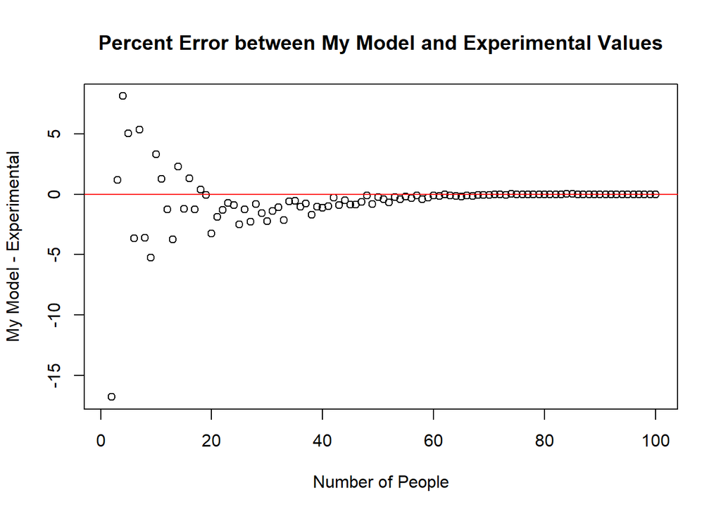

```r
library(ggplot2)
Theoretical_Probability = data.frame(theoryP)
morrin_Probability = data.frame(morrinP)
Simulated_Probability = data.frame(prob)

df = cbind(Simulated_Probability,Theoretical_Probability, morrin_Probability)
colnames(df) = c("Simulated Probability", "Theoretical Probability", "Morrin Probability")
df$Perecent_Error_My_Model = ((df$`Theoretical Probability`- df$`Simulated Probability`)/(df$`Theoretical Probability`)) * 100
df$index = 1:100
df$Perecent_Error_Morrin = ((df$`Morrin Probability`- df$`Simulated Probability`)/(df$`Morrin Probability`))* 100

#Error Plots
plot(df$Perecent_Error_My_Model, main = "Percent Error between My Model and Experimental Values", xlab = "Number of People",
     ylab = "My Model - Experimental")
abline(h = 0, col = "red")
```

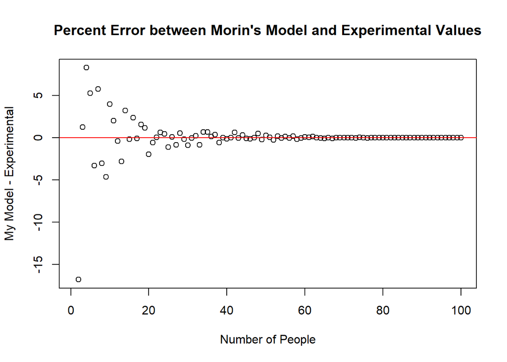

```r
plot(df$Perecent_Error_Morrin, main = "Percent Error between Morin's Model and Experimental Values",
     xlab = "Number of People", ylab = "My Model - Experimental")
abline(h = 0, col = "red")
```

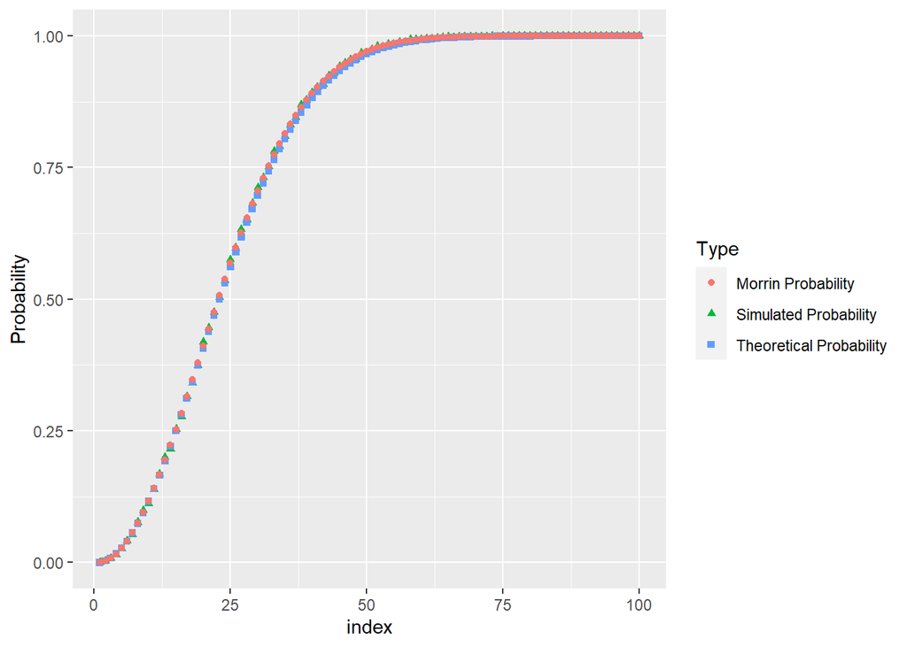

```r
dfModified = df %>%
  select(index, `Simulated Probability`, `Theoretical Probability`, `Morrin Probability`) %>%
  gather(key = "Type", value = "Probability", -index)

plot1 = ggplot(dfModified, aes(x = index, y = Probability, col = Type, shape = Type)) + geom_point()
plot1
```

Simulate Rooms of 23 people to test Theoretical models against each other

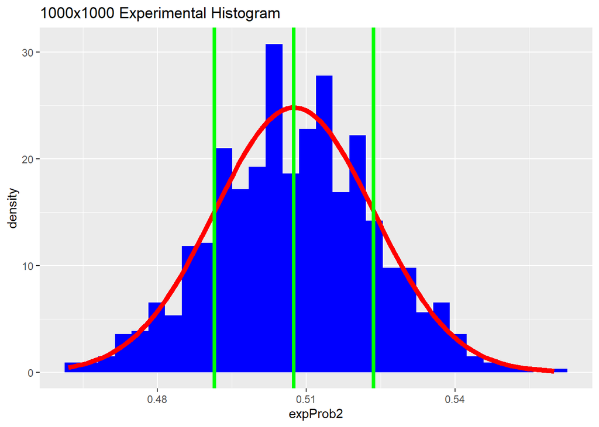

```r
startSize = 2
trials = 1000
sample_size = 1000
roomSize = 23

#calculate theoretical values
morrin = morrinModel(roomSize)
myModel = tprob(roomSize)

#simulate experiemental data to test against

expProb2 = vector()
#expProb3 = vector()

loopcontrol2 = 1
while(loopcontrol2 <= 1000){
  countFalse = 0
  countTrue = 0
  for(i in 1:1000){
    x = birthday(roomSize)
    y = ismatch(x)

    if(y == TRUE)
      countTrue = countTrue + 1
    if(y == FALSE)
      countFalse = countFalse + 1
  }

  expProb2[loopcontrol2] = countTrue/(countTrue + countFalse)

  loopcontrol2 = loopcontrol2 + 1
}

#plot a histogram of sampling distribution
expData = data.frame(expProb2)

hist1000x1000 = ggplot(expData, aes(x = expProb2)) + geom_histogram(aes(y = ..density..), fill = "blue")
hist1000x1000 = hist1000x1000 + stat_function(fun = dnorm, args = list(mean = mean(expProb2), sd = sd(expProb2)), col = "red", size = 2)
hist1000x1000 = hist1000x1000 + geom_vline(xintercept = mean(expProb2), col = "green", size = 1.5)
hist1000x1000 = hist1000x1000 + geom_vline(xintercept = mean((expProb2) + sd(expProb2)), col = "green", size = 1.5)
hist1000x1000 = hist1000x1000 + geom_vline(xintercept = mean((expProb2) - sd(expProb2)), col = "green", size = 1.5)
hist1000x1000 + ggtitle("1000x1000 Experimental Histogram")
```

```r
# expData3 = data.frame(expProb3)
# hist10000x1000 = ggplot(expData3, aes(x = expProb3)) + geom_histogram(aes(y = ..density..), fill = "blue")
# hist10000x1000 = hist10000x1000 + stat_function(fun = dnorm, args = list(mean = mean(expProb3), sd = sd(expProb3)), col = "red", size = 2)
# hist10000x1000 = hist10000x1000 + geom_vline(xintercept = mean(expProb3), col = "green", size = 1.5)
# hist10000x1000 = hist10000x1000 + geom_vline(xintercept = mean((expProb3) + sd(expProb3)), col = "green", size = 1.5)
# hist10000x1000 = hist10000x1000 + geom_vline(xintercept = mean((expProb3) - sd(expProb3)), col = "green", size = 1.5)
# hist10000x1000
```

Statistical Significance Test

```r
#Perform a t-test assuming that the theoretical value is the null.

#My Model
null1 = tprob(roomSize)
myTest = t.test(x = expProb2, mu = null1)
myTest
```

```
##
##  One Sample t-test
##
## data:  expProb2
## t = 13.898, df = 999, p-value < 2.2e-16
## alternative hypothesis: true mean is not equal to 0.5004772
## 95 percent confidence interval:
##  0.5065419 0.5085361
## sample estimates:
## mean of x
##  0.507539
```

```r
#Morin's Model
null2 = morrinModel(roomSize)
morinTest = t.test(x = expProb2, mu = null2)
morinTest
```

```
##
##  One Sample t-test
##
## data:  expProb2
## t = 0.47581, df = 999, p-value = 0.6343
## alternative hypothesis: true mean is not equal to 0.5072972
## 95 percent confidence interval:
##  0.5065419 0.5085361
## sample estimates:
## mean of x
##  0.507539
```

Conclusion: Although our model shares a similar error profile as Morin’s model at small values of n, Morin’s model is clearly a better theoretical solution to the problem statement. Furthermore, although our model was able to correct answer posed question, it is extremely ineffective at predicting the exact probablity. More specific for medium values of n, say 25-75, our model consistently underestimates the probability of finding at least one pair. Based on a two-sided t test, it is extreme unlikely that proability our model predicts for a room of 23 people is correct (p < 2.2e -16).

```r
#exactly one pair

noPair21 = 1
for(i in 1:21){
  noPair21 = noPair21 *((365-i)/365)
}
noPair21
```

```
## [1] 0.5243047
```

```r
guessProb = noPair21 * 210 * (1/365)
guessProb
```

```
## [1] 0.3016548
```

```r
numPairs = function(n){
  count = 0
  for(i in 1:(length(n) - 1)){
    for(j in (i + 1):length(n)){
      if(n[i] == n[j])
        count = count + 1
    }
  }
  return(count)
}

# x = birthday(23)
# x
# numPairs(x)
```

simulate and check the number of times we get exactly one pair

```r
expProb4 = vector()
loopcontrol3 = 0
while(loopcontrol3 <= 10000){
  countFalse = 0
  countTrue = 0
  for(i in 1:1000){
    x = birthday(23)
    y = numPairs(x)

    if(y == 1)
      countTrue = countTrue + 1
    else
      countFalse = countFalse + 1
  }

  expProb4[loopcontrol3] = countTrue/(countTrue + countFalse)

  loopcontrol3 = loopcontrol3 + 1
}

mean(expProb4)
```

```
## [1] 0.3635988
```

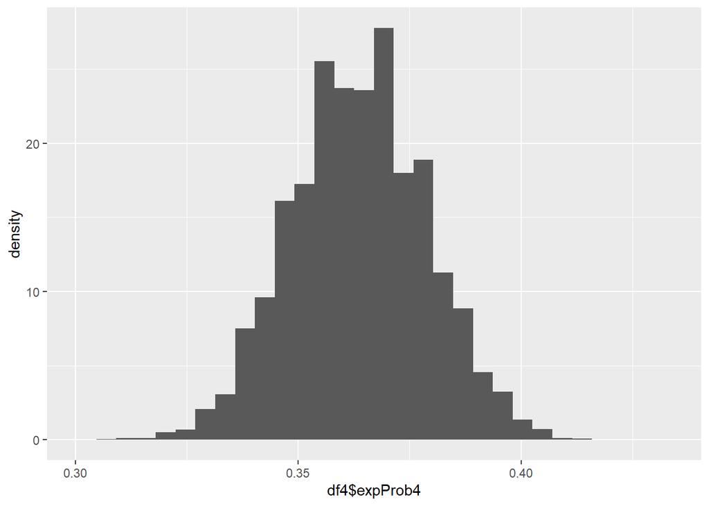

```r
df4 = data.frame(expProb4)
ggplot(data = df4, aes(x = df4$expProb4)) + geom_histogram(aes(y = ..density..))
```

Statistical Test against our theoretical guess

```r
guess = noPair21 * (1/365) * choose(23,2)

#t-test
t.test(x = expProb4, mu = guess)
```

```
##
##  One Sample t-test
##
## data:  expProb4
## t = 1.1647, df = 9999, p-value = 0.2442
## alternative hypothesis: true mean is not equal to 0.3634222
## 95 percent confidence interval:
##  0.3633015 0.3638961
## sample estimates:
## mean of x
## 0.3635988
```